# Lucky Penny

10/10/2018

## Reducing Number of Predictors In Predictive Analytics

- Stepwise Regression
- Any Mechanism Using Automated or Manual Steps

## Thought Experiment

### Find some lucky pennies

## Set It Up

```r
set.seed(123)
n_coins <- 50
tosses <- 10
p_heads <- 0.5
```

```r
results <- rbinom(n_coins, tosses, p_heads)
```

## What Is Surprising

```r
dbinom(7, tosses, p_heads)
```

```
## [1] 0.1171875
```

```r
dbinom(8, tosses, p_heads)
```

```
## [1] 0.04394531
```

```r
dbinom(9, tosses, p_heads)
```

```
## [1] 0.009765625
```

```r
dbinom(10, tosses, p_heads)
```

```
## [1] 0.0009765625
```

## This Is Surprising Enough (I think ??)

```r
surprise_threshhold <- 8
```

## Being the Geeks We Are

```r
picks <- seq_along(results)[results >= surprise_threshhold]
```

```r
picks
```

```
## [1] 11 20 24 31
```

```r
results[results >= surprise_threshhold]
```

```
## [1] 8 8 9 8
```

## What Did We Just Accomplish?

- I am pleased that I found so many valuable pennies out of 50.
- I have thoughtfully recorded how many heads I observed on each lucky penny so I do not need to do all that sampling stuff again.

## But We are Statisticians

```r
tosses_large <- 1000
pbinom(800, tosses_large, 0.5, lower.tail = FALSE)
```

```
## [1] 2.049443e-86
```

```r
pbinom(550, tosses_large, 0.5, lower.tail = FALSE)
```

```
## [1] 0.0006958708
```

```r
pbinom(525, tosses_large, 0.5, lower.tail = FALSE)
```

```
## [1] 0.05337477
```

```r
pbinom(526, tosses_large, 0.5, lower.tail = FALSE)
```

```
## [1] 0.04684365
```

## We’re Still Surprised

```r
surprise_threshhold_large <- 526
results_large <- rbinom(n_coins, tosses_large, p_heads)
picks_large <- seq_along(results_large)[results_large >= surprise_threshhold_large]
length(picks_large)
```

```
## [1] 4
```

```r
picks_large
```

```
## [1]  5 15 26 39
```

```r
results_large[results_large >= surprise_threshhold_large]
```

```
## [1] 528 533 531 539
```

## What Have We Seen?

- Root cause of where stepwise methods go wrong

## Stepwise Methods

- Forward Selection
- Backward Selection
- Stepwise Selection

## Stepwise Methods

- Forward Selection
  - Sequentially adds predictors having the most effect
  - Stop when no **significant** improvement can be obtained

## Stepwise Methods

- Backward Selection
  - Starts with full model
  - Predictors are removed one by one based on the least effect (\(F\) statistic)
  - Stop when all remaining predictors have F statistics at least as large as a **stay** threshold

## Stepwise Methods

- Stepwise Selection
  - Sequentially adds predictors having the most effect and greater than **entry** threshold
  - Removes predictors with effect less than **stay** threshold
  - Optional: Stop when no **significant** improvement can be obtained

## Statistical Issues

- Yields \(R^2\) values that are biased to be high
- Based on methods (e.g., \(F\) tests for nested models) intended to be used to test prespecified hypotheses
- \(F\) and \(\chi^2\) tests do not have their claimed distributions
- Yields \(p\)-values that do not have the proper meaning
- Gives biased regression coefficients that need shrinkage

## Effects Demonstrated in 1970’s and 1980’s

- Has severe problems in the presence of collinearity
- Does not select model having minumum mean residual squared error
- Users often attribute relative importance to order of when variables go in and out of model

## Effects Demonstrated in 1992 (1 of 6)

- Number of candidate predictor variables affected the number of noise variables that gained entry to the model

## Effects Demonstrated in 1992 (2 of 6)

- Number of candidate predictor variables affected the number of noise variables that gained entry to the model

  | Predictors | Noise | %Noise |
  | --- | --- | --- |
  | 12 | 0.43 | 20 |
  | 18 | 0.96 | 40 |
  | 24 | 1.44 | 46 |

## Effects Demonstrated in 1992 (3 of 6)

- Number of candidate predictor variables affected the number of noise variables that gained entry to the model
  - Effect of multicollinearity (correlation of 0.4)

  | Predictors | Noise | %Noise |
  | --- | --- | --- |
  | 12 | 0.47 | 35 |
  | 18 | 0.93 | 59 |
  | 24 | 1.36 | 62 |

## Effects Demonstrated in 1992 (4 of 6)

- Number of candidate predictor variables affected the number of noise variables that gained entry to the model

  | Predictors | Actual | Noise | %Noise |
  | --- | --- | --- | --- |
  | 12 | 1.70 | 0.43 | 20 |
  | 18 | 1.64 | 0.96 | 40 |
  | 24 | 1.66 | 1.44 | 46 |

## Effects Demonstrated in 1992 (5 of 6)

- Number of candidate predictor variables affected the number of noise variables that gained entry to the model
  - Effect of multicollinearity (correlation of 0.4)

  | Predictors | Actual | Noise | %Noise |
  | --- | --- | --- | --- |
  | 12 | 0.86 | 0.47 | 35 |
  | 18 | 0.87 | 0.93 | 59 |
  | 24 | 0.83 | 1.36 | 62 |

## Effects Demonstrated in 1992 (6 of 6)

- Number of candidate predictor variables affected the number of noise variables that gained entry to the model
- Authentic variables selected less than \(0.5\) the time
- Noise variables selected \(0.20\) to \(0.74\) of the time
- Increasing sample size does not help much
- \(R^2 \propto\) number candidate predictor variables and not the number of final predictor variables
- Method yields confidence intervals for effects and predicted values that are falsely narrow

## What If You Have Great Data

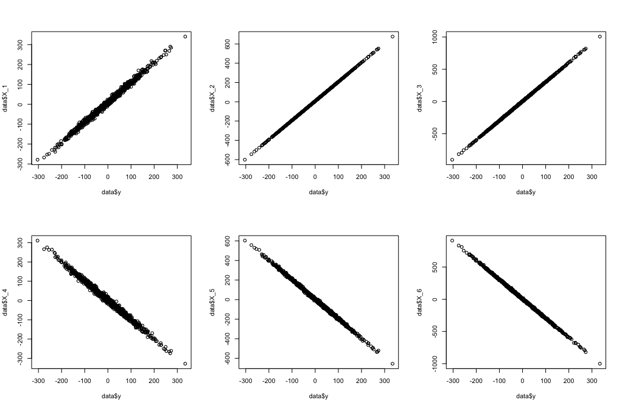

## And Noisy Noise

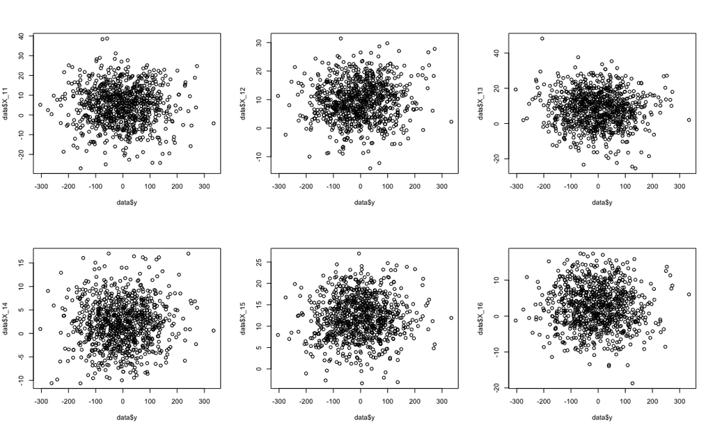

## You Pick Noise

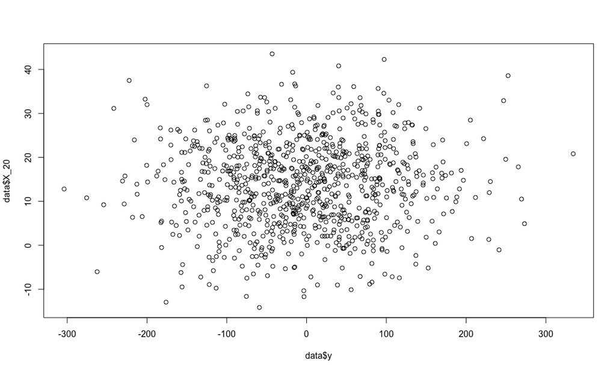

## What If You Change Thresholds

\(N = 900\)

| Predictors | Noise \(\alpha = 0.0016\) | Noise \(\alpha = 0.15\) |
| --- | --- | --- |
| 12 | 2 | 2 |
| 18 | 3 | 3 |
| 24 | 4 | 4 |
| 50 | 8 | 10 |
| 100 | 16 | 17 |

## Options

- Gold standard: know your domain, pick predictive variables, keep them all
- Least Absolute Shrinkage and Selection Operator (LASSO) or elastic nets if multicollinearity is a possibility.

## Lasso

\(min||\mathbf{y - X\beta}||^2\) subject to \(\sum\limits_{j=1}^{m} |\beta_{j}| \leq t\)

## Elastic Net

\(min||\mathbf{y - X\beta}||^2\) subject to \(\sum\limits_{j=1}^{m} |\beta_{j}| \leq t_1\), \(\sum\limits_{j=1}^{m} \beta_{j}^{2} \leq t_2\)